# Figure S5: ATAC enhancers known motif enrichment analysis

**Project:** Enhancer identification

**Author:** Jeff Johnston

**Generated:** Wed Aug 24 2016, 08:03 PM

## Region counts

| diff_bound_class | count |
| --- | --- |
| Higher in gd7 | 236 |
| Higher in Toll10b | 328 |
| No change | 15929 |

## Assign FlyBase gene IDs to known motifs

## Calculate enrichments

We can now test for enrichment of known motifs using the results from DESeq. We will use an adjusted p-value cutoff of 0.05. Each Nejire peak has been resized to 201 bp centered on the Nejire ChIP-seq summit.

We do not test the following motifs:

- All JASPAR_CORE motifs, as they are duplicates of JASPAR_2014
- All daughterless (da) hetereodimer motifs
- All motifs where the corresponding transcription factor is not expressed in any of the three tissues (FPKM > 5)

This results in 346 tested motifs.

After removal, we calculate an adjusted p-value for each motif enrichment test.

## Calculate overlap values for pairs of significant motifs

We next calculate the overlap between all pairs of 36 significant motifs.

## Enrichment and overlap heat maps

Motif overlap table

| keep_motif | other_names |
| --- | --- |
| FlyFactorSurvey-Abd.B_FlyReg_FBgn0000015 | FlyFactorSurvey-AbdB_SOLEXA_FBgn0000015 JASPAR_2014-hb-MA0049.1 |
| FlyFactorSurvey-Blimp.1_SANGER_5_FBgn0035625 | FlyFactorSurvey-Blimp.1_SANGER_5_FBgn0035625 |
| FlyFactorSurvey-CG16778_SANGER_5_FBgn0003715 | FlyFactorSurvey-CG16778_SANGER_5_FBgn0003715 |
| FlyFactorSurvey-dl_NBT_FBgn0000462 | FlyFactorSurvey-lola.PC_SANGER_5_FBgn0005630 JASPAR_2014-dl_1-MA0022.1 JASPAR_2014-dl_2-MA0023.1 FlyFactorSurvey-dl_FlyReg_FBgn0000462 |
| FlyFactorSurvey-En_Cell_FBgn0000577 | FlyFactorSurvey-Eve_Cell_FBgn0000606 FlyFactorSurvey-Dll_Cell_FBgn0000157 FlyFactorSurvey-Eve_SOLEXA_FBgn0000606 FlyFactorSurvey-Hbn_SOLEXA_FBgn0008636 FlyFactorSurvey-tup_SOLEXA_10_FBgn0003896 FlyFac… |
| FlyFactorSurvey-hb_SOLEXA_5_FBgn0001180 | FlyFactorSurvey-hb_SANGER_2.5_FBgn0001180 |
| FlyFactorSurvey-kay_Jra_SANGER_5_FBgn0001291 | FlyFactorSurvey-kay_Jra_SANGER_5_FBgn0001297 |
| FlyFactorSurvey-kni_SANGER_5_FBgn0001320 | FlyFactorSurvey-kni_SANGER_5_FBgn0001320 |
| FlyFactorSurvey-nub_FlyReg_FBgn0085424 | FlyFactorSurvey-nub_FlyReg_FBgn0085424 |
| FlyFactorSurvey-slp1_NAR_FBgn0003430 | JASPAR_2014-slp1-MA0458.1 |
| FlyFactorSurvey-sna_SOLEXA_5_FBgn0003448 | FlyFactorSurvey-CG17181_SOLEXA_5_FBgn0035144 FlyFactorSurvey-esg_SANGER_2.5_FBgn0001981 FlyFactorSurvey-sna_SANGER_10_FBgn0003448 |
| FlyFactorSurvey-Tin_SOLEXA_FBgn0004110 | FlyFactorSurvey-Tin_SOLEXA_FBgn0004110 |
| FlyFactorSurvey-vfl_SANGER_5_FBgn0259789 | FlyFactorSurvey-vfl_SOLEXA_5_FBgn0259789 |
| FlyFactorSurvey-Zen_Cell_FBgn0004053 | FlyFactorSurvey-Zen_SOLEXA_FBgn0004053 JASPAR_2014-eve-MA0221.1 JASPAR_2014-zen-MA0256.1 |

Motif pairs with more than 10% overlapping instances are combined, selecting the motif with the best p-value.

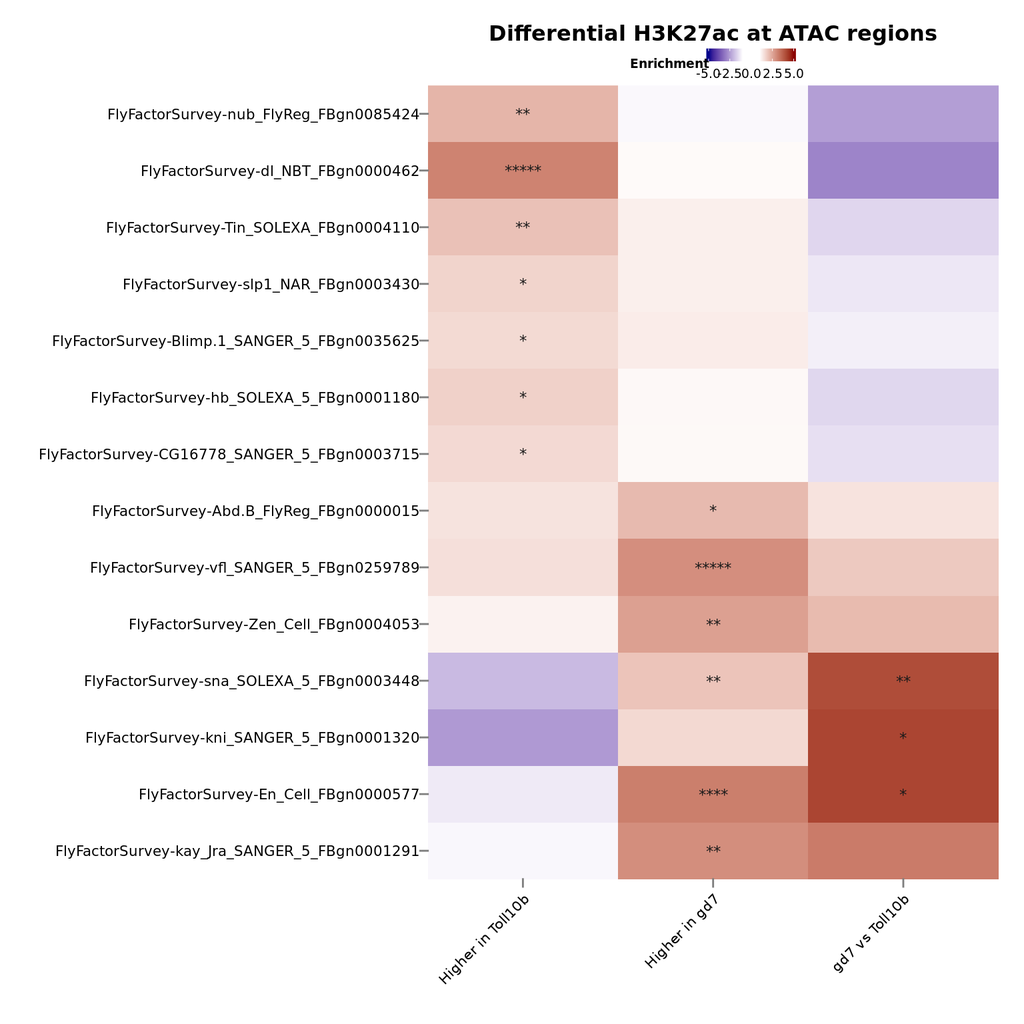

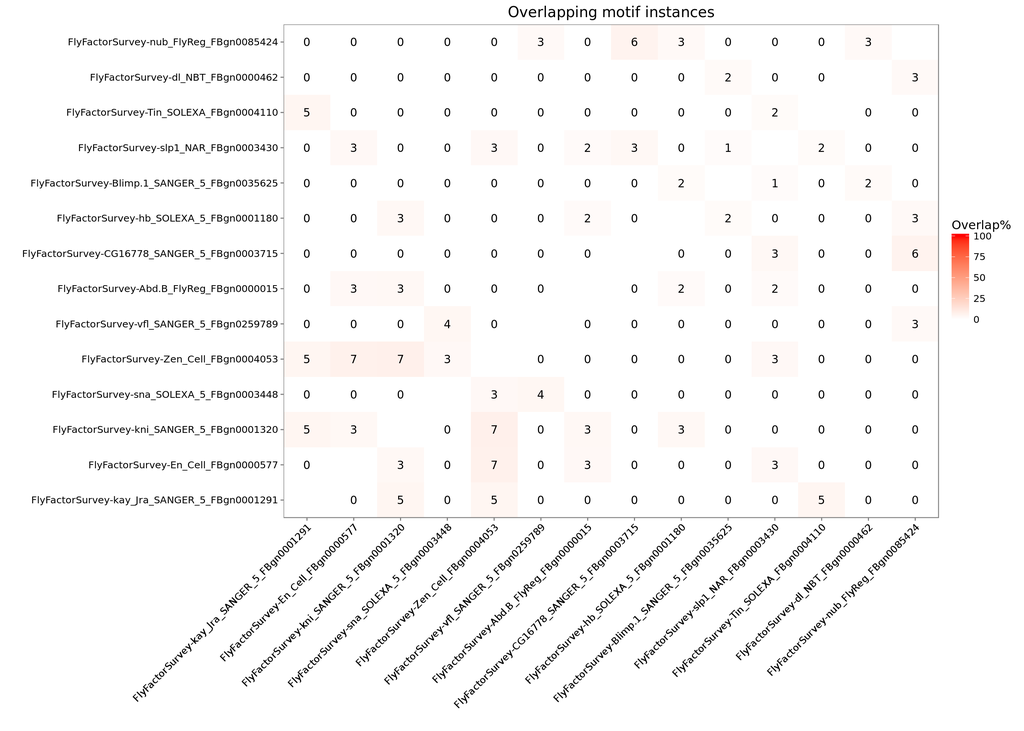

## Individual motifs

A PDF of motif logos for all significant motifs has been generated in the output folder for this document.